# REKURSIF

Berikut beberapa aturan dalam teknik pemrograman rekursif: Fungsi rekursif harus memiliki base case, base case inilah yang berfungsi untuk menghentikan pemanggilan terus menerus fungsi rekursif fungsi rekursif harus memiliki sintaks yang dapat merubah state dari permasalahan, sehingga semakin lama solusi permasalahan menuju base case yang sudah dibuat Fungsi rekursif harus memanggil dirinya sendiri

## IMPLEMENTASI REKURSIF

**Triangular Numbers**

Terdapat deret bilangan berikut : 1, 3, 6, 10, 15, 21, 28, 36, ... Bagaimanakah pola bilangan tersebut ? Deret bilangan tersebut dikenal dengan nama Triangular Numbers, yang dapat diilustrasikan seperti Gambar 1 berikut.

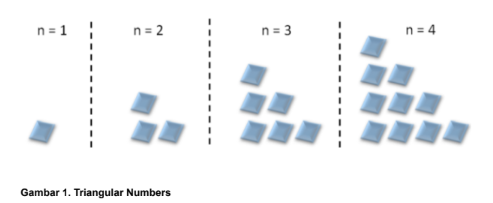

Bagaimana menentukan bilangan ke- dari deret tersebut ? Ilustrasi perhitungan deret keempat dari triangular numbers dapat dilihat pada Gambar 2 berikut:

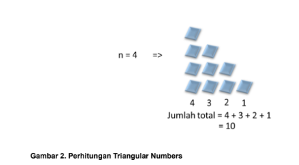

```python
def triangularNumbers2(n):
    if n == 1:
        return 1
    else:
        return n + triangularNumbers2(n - 1)

print(triangularNumbers1(2))
```

[output not shown]

**Konversi Bilangan**

Bilangan integer dikenal juga sebagai bilangan dengan base 10 (desimal), sehingga memiliki kemungkinan character angka dari 0 s.d 9. Sedangkan base 2 atau yang dikenal nama bilangan biner, hanya memiliki kemungkinan character angka 0 dan 1 saja. Base 8 atau octal, hanya memiliki character 0 s.d 7, sedangkan base 16 atau hexa, memiliki character angka mulai dari 0 s.d 9 dan 'A','B','C','D','E', dan 'F'. Masing-masing bilangan ini dapat dikonversikan menjadi bilangan base lain, akan tetapi yang sering digunakan adalah konversi bilangan desimal ke bilangan base yang lain, atau dari base 2, 8, 16 ke bilangan desimal. Berikut contoh konversi bilangan desimal ke bilangan base 2, 8, atau 16. Bilangan desimal 8 menjadi bilangan biner '1000'. Untuk merubah bilangan desimal 8 menjadi biner, diperlukan operasi pembagian dan modulo dari bilangan desimal tersebut.

```python
def konversiDesimal(bilangan, base):
    charBilangan = '0123456789ABCDEF'

    if bilangan < base:
        return charBilangan[bilangan]
    else:
        temp = bilangan // base
        ind = bilangan % base

        print(type(temp), temp, type(ind), ind)

        return konversiDesimal(temp, base) + charBilangan[ind]

konversiDesimal(5,2)
```

```
<class 'int'> 2 <class 'int'> 1
<class 'int'> 1 <class 'int'> 0
```

```
'101'
```

```python
def hanoi(n, asal, tujuan, bantu):
    if n == 1:
        print(f"Pindah piringan 1 dari {asal} ke {tujuan}")
    else:
        hanoi(n-1, asal, bantu, tujuan)
        print(f"Pindah piringan {n} dari {asal} ke {tujuan}")
        hanoi(n-1, bantu, tujuan, asal)
hanoi(3, 'A', 'C', 'B')
```

```
Pindah piringan 1 dari A ke C
Pindah piringan 2 dari A ke B
Pindah piringan 1 dari C ke B
Pindah piringan 3 dari A ke C
Pindah piringan 1 dari B ke A
Pindah piringan 2 dari B ke C
Pindah piringan 1 dari A ke C
```